# ANN Architecture Exploration

Alexis Navarra, Giselle Ramirez, Nealson Setiawan, Sammy Suliman

2022-12-05

# Introduction

This vignette report outlines the process of our exploration of Neural Network Architecture and how it affects the outcome of the model. Below, we will summarize our background research on the different aspects of neural network architecture, the data we decided to conduct our exploration with, how we tested the different aspects of neural netnarchitecture, and our conclusions as to how changes to the architecture affected the outcome of our model fitting.

# Neural Network Architecture Background

## Layers

An artificial neural network is constructed of three types of layers:

- Input Layer: where the initial data is taken in
- Output Layer: where the results are produced for given inputs
- Hidden Layers: where all of the computation is done, between the input and output layers

The hidden layers are composed of ‘activation nodes’, each having functions that pre-determine to what extent the node will be ‘activated’ based on the given weight. The weight is what connects the nodes between the neighboring layers. This weight is thought of as the “impact that that node has on the node from the next layer” (Towards Data Science).

The weights between neural network layers can be quantified as a matrix, which we can call $\theta$. If a network has $a$ units in layer $j$ and $b$ units in layer $(j+1)$, then $\theta_j$ will have dimensions $b*(a+1)$:
$$\theta_j =
\begin{bmatrix}
\theta_{1,1} & \theta_{1,2} & \dots & \theta_{1,(a+1)} \\
\theta_{2,1} & \theta_{2,2} & \dots & \theta_{2,(a+1)} \\
\vdots & \vdots & \ddots & \vdots \\
\theta_{b,1} & \theta_{b,2} & \dots & \theta_{b,(a+1)} \\
\end{bmatrix}$$

To compute the activation nodes, say $a^{(L)}_n$ where L is the number of layers with n nodes, for each of the hidden layers, we would multiply an input vector, say $X$, by the weights $\theta$, and then apply the activation function, $g$, to get something like this:

$$a^{(L)}_1 = g(\theta_{1,1}x_1 + \theta_{1,2}x_2 + \dots + \theta_{1,
(a+1)}x_k) \\
a^{(L)}_2 = g(\theta_{2,1}x_1 + \theta_{2,2}x_2 + \dots + \theta_{2,
(a+1)}x_k) \\
\vdots \\
a^{(L)}_n = g(\theta_{b,1}x_1 + \theta_{b,2}x_2 + \dots + \theta_{b,
(a+1)}x_k)$$

## Activation Functions

Like we noted earlier, the activation function pre-determines whether each node should be ‘activated’ or not based on the weighted sum value. The main goal of the activation function is to take the weighted input from a node and output a value that is then either fed into the next hidden layer or sent as an output. It is used to introduce non-linearity into neural networks.

The activation function within a neural network works differently depending on the flow of information within that neural network. This movement of information can be described as either Feedforward or Back Propagation within the context of neural networks (V7 Labs).

#### Feedforward Propagation:

When the flow of information in a neural network moves in a forward direction. The input is used for calculations in the hidden layer, and those calculations in the hidden layer are used to calculate the output value. Here, the activation function acts as a “gate” between what goes into the input layer and its output into the next hidden layer (V7 Labs).

#### Back Propagation:

When the network’s weights and biases are adjusted repeatedly in hopes of minimizing the difference between the real output vector of the neural net and the predicted output vector of the neural net. This difference is called the cost function, and its gradients determine the level of adjustment with respect to the activation function, weight, bias, etc. (V7 Labs).

#### Common Activation Functions:

- Identity: $\sigma(x)=x$ - This is the most basic linear function.
- Sigmoid: $\sigma(x)=\frac{1}{1+e^{-x}}$
  - The sigmoid activation function provides the advantage of not being linear and thus serving as a superior approximator for nonlinear functions, which comprise the majority of functions.
- Hyperbolic tangent: $\sigma(x)=\frac{e^x - e^{-x}}{e^x+e^{-x}}$
  - Similar to sigmoid, hyperbolic tangent has an advantage in having a steeper gradient, which allows faster learning.
- Rectified linear unit: $\sigma(x)=\text{max}(0,x)$
  - The advantage of this activation function is that it does not activate all linear units at the same time.

## Epochs

An epoch is the interval in which the neural network completes everything. In one epoch, you pass in all of your parameters, calculate the loss according to your metric, and compute the partial derivatives of the loss function, and update the resultant weights on the neural network through backpropagation. An epoch is effectively the number of times the neural network “sees” the dataset.

Generally, we do not feed all of the data into the model all at the same time, but rather in “batches”. The batch size is the number of training examples in one forward pass and resultant backwards pass through the model. The number of epochs is determined by the training and validation error. So long as the error rate continues to drop, we should continue updating our model.

An iteration is the number of steps in a single batch. So if we have 100 total data points in our training set, and 5 batches, we would need 20 iterations to complete one iteration.

# Architecture Exploration Results

## Using Artificial Neural Networks for Regression

We chose to conduct our exploration using the abalone dataset built into R. The dataset contains data on 4177 abalones with feature variables such as type (male, female, or infant), diameter, height, longest shell measurements, and various weights. Our target variable, and what we are trying to predict, is the age of the abalone. The data is supervised, as this target can be calculated by adding 1.5 to the number of rings.

## Layers and Nodes Exploration

### MSE

To see if having single layers or multiple layers plays a role in improving MSE (mean square error), we decided to have three examples for each single layer ANN and multiple-layer ANN, using a Logistic Regression activation function and setting the algorithm to “rprop+”.

For single layer, we set models to 1, 5, 6 hidden nodes for the single layer as shown below:

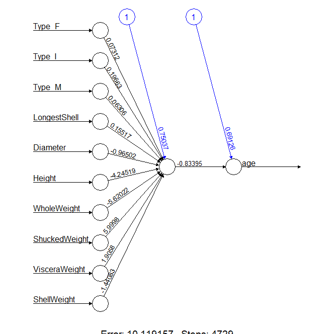

Single layer with 1 node. MSE: 10.78287

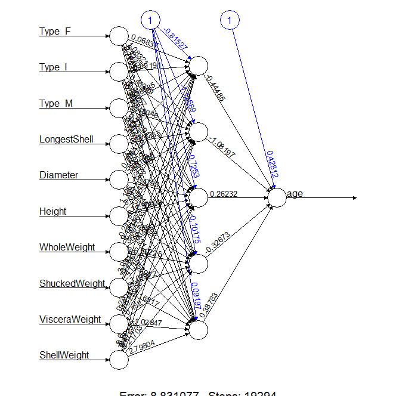

Single layer with 5 nodes. MSE: 10.04245

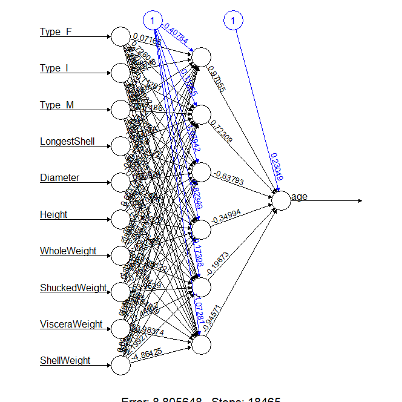

Single layer with 6 nodes. MSE: 9.991573

However, in the case for multiple-layer ANN, we see something different. We set models to 2 by 2, 5 by 3, and 8 by 6 hidden nodes for the multiple layer as shown below:

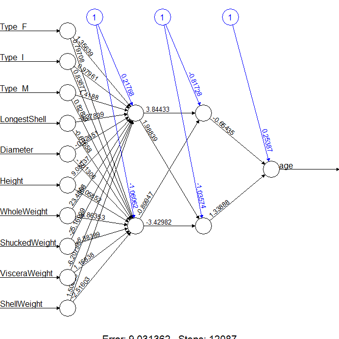

Multiple layer with 2 by 2 nodes. MSE: 9.967073

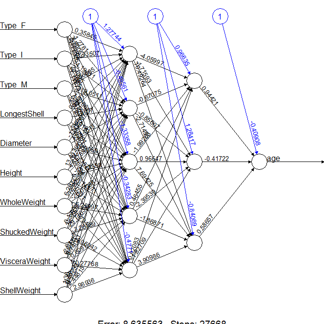

Multiple layer with 5 by 3 nodes. MSE: 10.01608

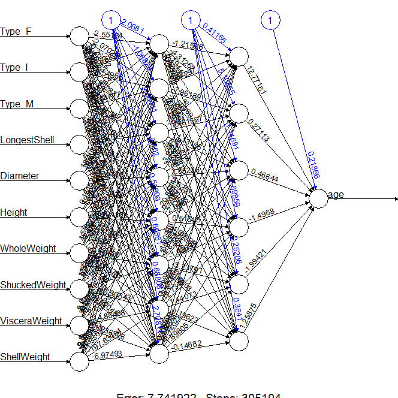

Multiple layer with 8 by 6 nodes. MSE: 10.33044

In this case, with just the 2 nodes per layer, we already see that the MSE is already lower than all previous examples with a single layer. However, once we increase the first and second layer, the MSE increases. This indicates that there is more nodes than needed and may be a sign of over training. This indicates that the best model is where there is more nodes for a single layer or less nodes for a multiple layer for this dataset. In our case, the 2 by 2 multiple layer is our best model as it has the lowest MSE.

### R-squared (measuring predictability of models)

We can also measure if single layer is better than multiple layers in the sense that it could accurately measure the actual values of the abalone age. We plotted a fitted weighted plot for each of the 6 models above that shows the relationship between predicted values (y axis) and actual values (x axis):

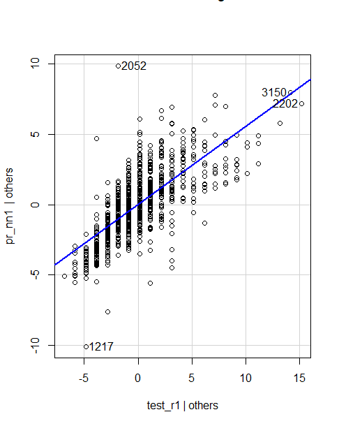

Single layer with 1 node. R-squared: 0.5169197

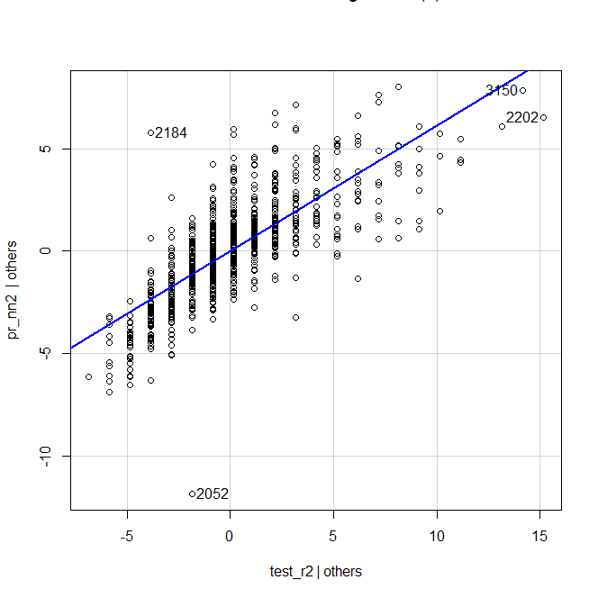

Single layer with 5 nodes. R-squared: 0.5885074

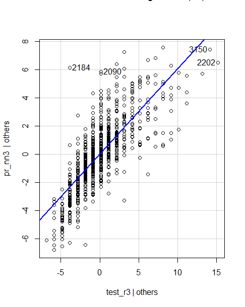

Single layer with 6 nodes. R-squared: 0.5931386

Now on to the multiple layers. We see a different case for the models to 2 by 2, 5 by 3, and 8 by 6 hidden nodes as shown below:

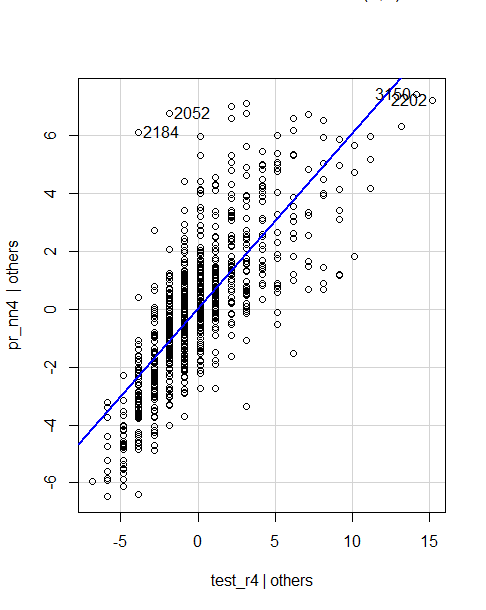

Multiple layer with 2 by 2 nodes. R-squared: 0.5839595

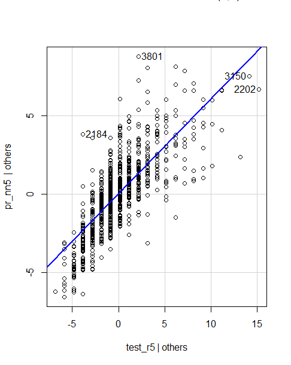

Multiple layer with 5 by 3 nodes. R-squared: 0.5912586

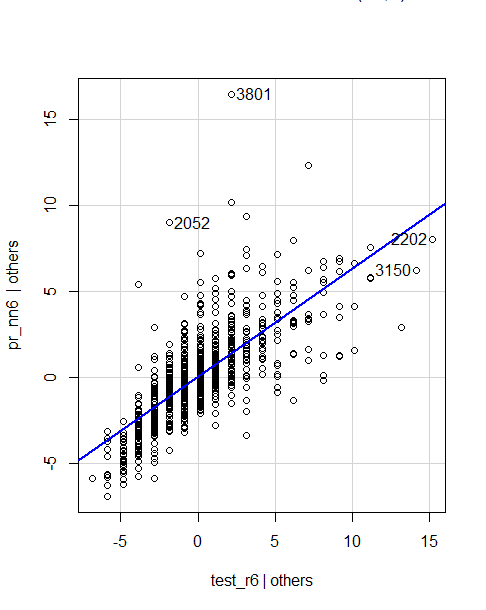

Multiple layer with 8 by 6 nodes. R-squared: 0.5419721

As seen here, as the nodes increase for multiple layer ANN, we see R-square increase, until it reaches too many nodes as shown by the 8 by 6 nodes, where weighted R-square decreased. Overall, we see that our model for single layer of 6 nodes had the best weighted R-squared, meaning its predicted values were very similar to its actual values with a strong correlation of almost 0.6. However, all models had an R-square of over 0.5, indicating that all models did a pretty good job of estimating our real values of abalone age.

## Epochs Exploration

To explore how the number of epochs in our neural network affected the outcome of the regression task, we build a neural net model and ran it using various numbers of epochs. We set the model to have three hidden layers, a Rectified Linear Unit activation function, and a validation split set to 0.3.

We ran the model with 10, 50, and 100 epochs and compared the results of each run, shown below:

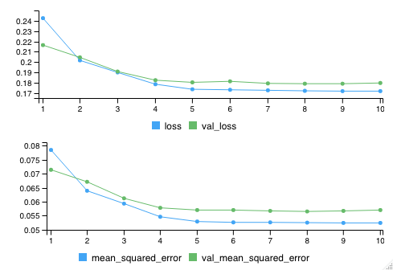

Neural net with 10 epochs

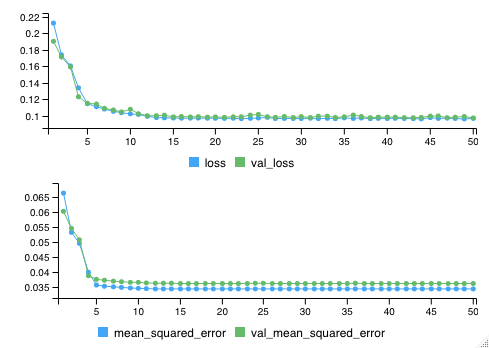

Neural net with 50 epochs

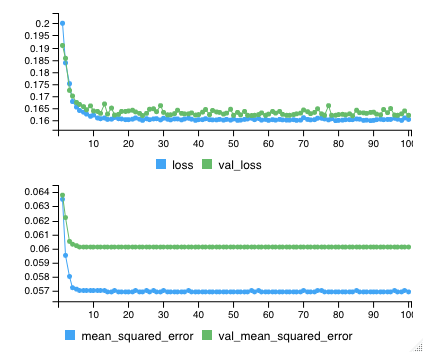

Neural net with 100 epochs

## Hyperparameter Tuning

As shown previously, the choice of hyperparameters like epochs and number of nodes are important in producing an accurate model. In fact, finding the optimal choice of hyperparameters is called **tuning**. There are many ways to do this such as:

- Grid Search: In this method, we manually choose a collection of values to be used as hyperparameters and choose the best one at the end.
- Random Search: In this method, we instead choose the range of values that can be used and the model randomly selects a random combination of values to be used as hyperparameters.
- Bayesian Optimization: In this method, the model first arbitrarily chooses an initial random combination of values to be used as hyperparameters. However, on every iteration, it chooses the next point by deciding between choosing a point with the most uncertainty (known as **active learning**) which might unexpectedly have great results (known as **exploration**), or going to the point where it is expected to have great results (known as **exploitation**).

But how does Bayesian Optimization decides which choice to pursue? It uses acquisition functions, and decides by maximizing such functions.

### Acquisition Functions:

#### Upper Confidence Bound (UCB):

$$UCB(x)=\mu(x)+\kappa\sigma(x)$$

In this acquisition function, exploitation is signified by the mean depicted as *mu*, and the uncertainty is signified as *sigma*, while lambda is the exploration parameter, depicted as *kappa*, and is used to control the ‘preference’ between exploration and exploitation. At every iteration, the query points with higher UCB dictates where the model will train at.

#### Probability of improvement (PI):

$$PI(x)=\Phi\left(\frac{\mu(x)-f{max}-\varepsilon}{\sigma(x)}\right)$$

In this function, the next point will be determined by choosing the point with the greatest probability of improvement over the current maximum. After assuming that the probability of improvement follows a Gaussian distribution, this is determined by the gaussian CDF of the mean, f_max, which is the current maximum, sigma, and a parameter epsilon. This acquisition function uses the parameter, depicted as epsilon, is used to control the ‘preference’ between exploration and exploitation, as larger epsilon value causes less emphasis on exploration.

#### Expected Improvement (EI):

$$EI(x) =
\left(\mu(x)-f_{max}\right)\Phi\left(\frac{\mu(x)-f{max}-\varepsilon}{\sigma(x)}\right)+\sigma(x)\phi\left(\frac{\mu(x)-f{max}-\varepsilon}{\sigma(x)}\right)$$

In this function, the next point is determined by choosing the point which has the most expected improvement over the current maximum, depicted by f_max. Thus, from the function, we can see that the function is high when either the difference between the mean and current maximum, or when the uncertainty around sigma is great. Like previously, we use epsilon to encourage or discourage exploration.